# IS605-Assignment11

Joseph Elikishvili

April 24, 2017

## Part 1

```r
Age  = c(18, 23, 25, 35, 65, 54, 34, 56, 72, 19, 23, 42, 18, 39, 37)
MaxHR = c(202, 186, 187, 180, 156, 169, 174, 172, 153, 199, 193, 174, 198, 183, 178)

result = lm(MaxHR~Age)
summary(result)
```

```
##
## Call:
## lm(formula = MaxHR ~ Age)
##
## Residuals:
##     Min      1Q  Median      3Q     Max
## -8.9258 -2.5383  0.3879  3.1867  6.6242
##
## Coefficients:
##              Estimate Std. Error t value Pr(>|t|)
## (Intercept) 210.04846    2.86694   73.27  < 2e-16 ***
## Age          -0.79773    0.06996  -11.40 3.85e-08 ***
## ---
## Signif. codes:  0 '***' 0.001 '**' 0.01 '*' 0.05 '.' 0.1 ' ' 1
##
## Residual standard error: 4.578 on 13 degrees of freedom
## Multiple R-squared:  0.9091, Adjusted R-squared:  0.9021
## F-statistic:   130 on 1 and 13 DF,  p-value: 3.848e-08
```

Based on above output, we get the following equasion: MaxHR = 210.04846 - 0.79773*Age

The Adjusted R-2 is 0.9021 which is pretty hight and indicates that the effect is significant. The low p-value is another strong indication of the above.

Next we will plot the fitted relationship between Max HR and Age

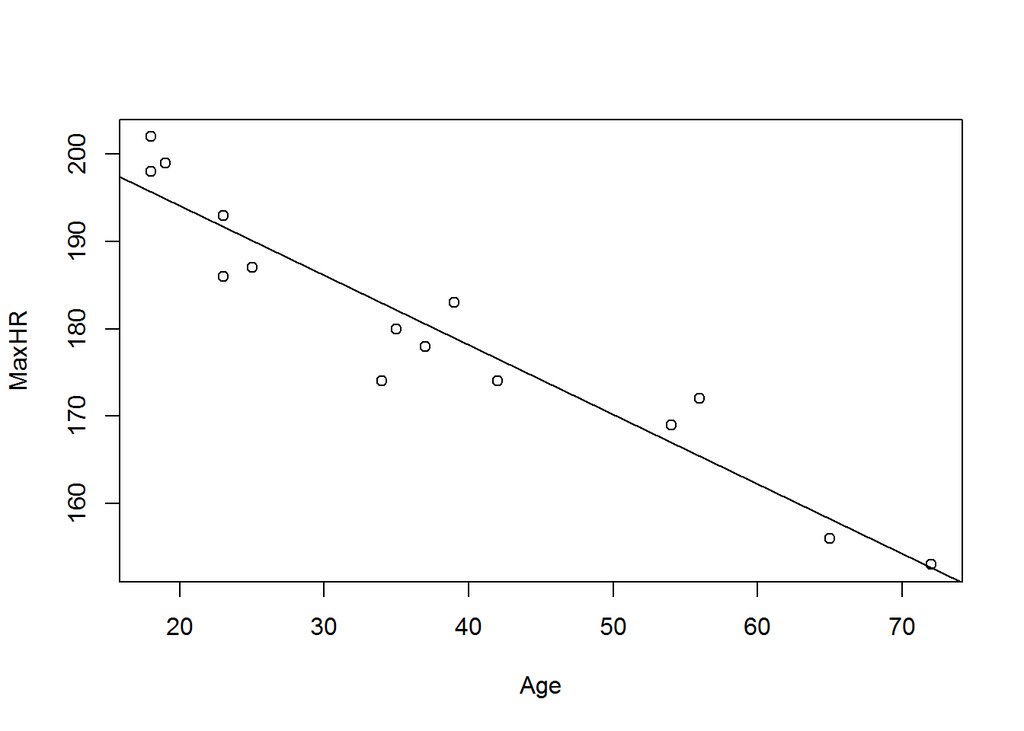

```r
reg1 = lm(MaxHR ~ Age)

plot(Age,MaxHR)
abline(reg1)
```

## Part 2

#### Using the Auto data set from Assignment 5 (also attached here) perform a Linear Re-gression analysis using mpg as the dependent variable and the other 4 (displacement, horse-power, weight, acceleration) as independent variables. What is the final linear regression fit equation? Which of the 4 independent variables have a significant impact on mpg? What are their corresponding significance levels? What are the standard errors on each of the coeficients?

```r
cars = read.table("c:/data/auto-mpg.data")
colnames(cars) = c('displacement', 'hp', 'weight', 'acceleration', 'mpg')
tail(cars)
```

```
##     displacement hp weight acceleration mpg
## 387          151 90   2950         17.3  27
## 388          140 86   2790         15.6  27
## 389           97 52   2130         24.6  44
## 390          135 84   2295         11.6  32
## 391          120 79   2625         18.6  28
## 392          119 82   2720         19.4  31
```

```r
cars_reg=lm(mpg ~ displacement+hp+weight+acceleration, data = cars)
summary(cars_reg)
```

```
##
## Call:
## lm(formula = mpg ~ displacement + hp + weight + acceleration,
##     data = cars)
##
## Residuals:
##     Min      1Q  Median      3Q     Max
## -11.378  -2.793  -0.333   2.193  16.256
##
## Coefficients:
##                Estimate Std. Error t value Pr(>|t|)
## (Intercept)  45.2511397  2.4560447  18.424  < 2e-16 ***
## displacement -0.0060009  0.0067093  -0.894  0.37166
## hp           -0.0436077  0.0165735  -2.631  0.00885 **
## weight       -0.0052805  0.0008109  -6.512  2.3e-10 ***
## acceleration -0.0231480  0.1256012  -0.184  0.85388
## ---
## Signif. codes:  0 '***' 0.001 '**' 0.01 '*' 0.05 '.' 0.1 ' ' 1
##
## Residual standard error: 4.247 on 387 degrees of freedom
## Multiple R-squared:  0.707,  Adjusted R-squared:  0.704
## F-statistic: 233.4 on 4 and 387 DF,  p-value: < 2.2e-16
```

Based on the above, the final equasion is: 45.2511397 - 0.0060009*Dispalacement -0.0436077*hp -0.0052805*weight -0.0231480*acceleration

Based on the p-vales we can state that hp and weight are have significant impact on mpg, and displacement and acceleration do not have significant impact since their p-vales are > 0.05. We can further test this by recaculating adjusted R2 after we eliminate them one by one

```r
#Removed displacement
cars_reg_test=lm(mpg ~ hp+weight+acceleration, data = cars)
summary(cars_reg_test)
```

```
##
## Call:
## lm(formula = mpg ~ hp + weight + acceleration, data = cars)
##
## Residuals:
##     Min      1Q  Median      3Q     Max
## -11.079  -2.736  -0.331   2.170  16.262
##
## Coefficients:
##                Estimate Std. Error t value Pr(>|t|)
## (Intercept)  45.6782929  2.4085431  18.965  < 2e-16 ***
## hp           -0.0474956  0.0159891  -2.970  0.00316 **
## weight       -0.0057894  0.0005776 -10.024  < 2e-16 ***
## acceleration -0.0020657  0.1233378  -0.017  0.98665
## ---
## Signif. codes:  0 '***' 0.001 '**' 0.01 '*' 0.05 '.' 0.1 ' ' 1
##
## Residual standard error: 4.246 on 388 degrees of freedom
## Multiple R-squared:  0.7064, Adjusted R-squared:  0.7041
## F-statistic: 311.1 on 3 and 388 DF,  p-value: < 2.2e-16
```

```r
#Removed acceleration
cars_reg_test=lm(mpg ~ hp+weight+displacement, data = cars)
summary(cars_reg_test)
```

```
##
## Call:
## lm(formula = mpg ~ hp + weight + displacement, data = cars)
##
## Residuals:
##      Min       1Q   Median       3Q      Max
## -11.3347  -2.8028  -0.3402   2.2037  16.2409
##
## Coefficients:
##                Estimate Std. Error t value Pr(>|t|)
## (Intercept)  44.8559357  1.1959200  37.507  < 2e-16 ***
## hp           -0.0416741  0.0128139  -3.252  0.00125 **
## weight       -0.0053516  0.0007124  -7.513 4.04e-13 ***
## displacement -0.0057688  0.0065819  -0.876  0.38132
## ---
## Signif. codes:  0 '***' 0.001 '**' 0.01 '*' 0.05 '.' 0.1 ' ' 1
##
## Residual standard error: 4.241 on 388 degrees of freedom
## Multiple R-squared:  0.707,  Adjusted R-squared:  0.7047
## F-statistic:   312 on 3 and 388 DF,  p-value: < 2.2e-16
```

```r
#Now lets remove weight since it has the lowest p-value
cars_reg_test=lm(mpg ~ displacement+hp+displacement, data = cars)
summary(cars_reg_test)
```

```
##
## Call:
## lm(formula = mpg ~ displacement + hp + displacement, data = cars)
##
## Residuals:
##      Min       1Q   Median       3Q      Max
## -11.3674  -3.1721  -0.4338   2.3349  16.4288
##
## Coefficients:
##               Estimate Std. Error t value Pr(>|t|)
## (Intercept)  37.469488   0.727716  51.489  < 2e-16 ***
## displacement -0.040818   0.004963  -8.225 2.95e-15 ***
## hp           -0.058275   0.013491  -4.319 1.99e-05 ***
## ---
## Signif. codes:  0 '***' 0.001 '**' 0.01 '*' 0.05 '.' 0.1 ' ' 1
##
## Residual standard error: 4.534 on 389 degrees of freedom
## Multiple R-squared:  0.6643, Adjusted R-squared:  0.6626
## F-statistic: 384.9 on 2 and 389 DF,  p-value: < 2.2e-16
```

We can clearly see that removeing acceleration or displacement has pretty insignificant affect on R2, so they dio not seem to be hurtiung the model but definately do not help it. But when we removed weight the R2 dropped.

#### Please perform this experiment in two ways. First take any random 40 data points from the entire auto data sample and perform the linear regression fit and measure the 95% confidence intervals. Then, take the entire data set (all 392 points) and perform linear regression and measure the 95% confidence intervals. Please report the resulting fit equation, their significance values and confidence intervals for each of the two runs.

```r
library(dplyr)
#Get a sample of 40
cars_sample = sample_n(cars, 40)

#run lm on a sample.
sample_reg=lm(mpg ~ displacement+hp+weight+acceleration, data = cars_sample)
summary(sample_reg)
```

```
##
## Call:
## lm(formula = mpg ~ displacement + hp + weight + acceleration,
##     data = cars_sample)
##
## Residuals:
##     Min      1Q  Median      3Q     Max
## -9.6240 -2.6332  0.0924  1.6575  7.5466
##
## Coefficients:
##               Estimate Std. Error t value Pr(>|t|)
## (Intercept)  42.443741   8.302664   5.112 1.14e-05 ***
## displacement -0.019573   0.021005  -0.932   0.3578
## hp           -0.097112   0.056753  -1.711   0.0959 .
## weight       -0.001628   0.002515  -0.647   0.5217
## acceleration -0.092765   0.380748  -0.244   0.8089
## ---
## Signif. codes:  0 '***' 0.001 '**' 0.01 '*' 0.05 '.' 0.1 ' ' 1
##
## Residual standard error: 3.655 on 35 degrees of freedom
## Multiple R-squared:  0.7433, Adjusted R-squared:  0.714
## F-statistic: 25.34 on 4 and 35 DF,  p-value: 6.466e-10
```

```r
output = function(x)
{
  sprintf(paste0(x$coefficients[1], '   +(', x$coefficients[2], '*', 'Displacement', ')   +(', x$coefficients[3], '*','HP', ')   +(', x$coefficients[4], '*','Weight', ')   (', x$coefficients[5],'*','Acceleration)'))
}

output(sample_reg)
```

```
## [1] "42.4437406656697   +(-0.019573107681478*Displacement)   +(-0.0971115676619601*HP)   +(-0.00162770075968824*Weight)   (-0.0927648460719524*Acceleration)"
```

The above is the final equasion of the sample of 40.

```r
#95% confidence interval of sample data
confint(sample_reg, level=0.95)
```

```
##                     2.5 %      97.5 %
## (Intercept)  25.588437382 59.29904395
## displacement -0.062215647  0.02306943
## hp           -0.212326853  0.01810372
## weight       -0.006733151  0.00347775
## acceleration -0.865725036  0.68019534
```

```r
#95% confidence interval of original data
confint(cars_reg, level=0.95)
```

```
##                     2.5 %       97.5 %
## (Intercept)  40.422278855 50.080000544
## displacement -0.019192122  0.007190380
## hp           -0.076193029 -0.011022433
## weight       -0.006874738 -0.003686277
## acceleration -0.270094049  0.223798050
```